# 函數

## 郭耀仁

## 函數是什麼？

- 我們把函數拆分成三個元件：
  - 輸入（input）
  - 參數（arguments, 常縮寫為 args）
  - 輸出（output）

[figure not shown]

## 內建函數

https://docs.python.org/3/library/functions.html

```python
distances = [1.6, 3, 5, 10, 21, 42.195]

# 應用函數
print(max(distances)) # 最長的距離
print(min(distances)) # 最短的距離
print(len(distances)) # 總共有幾個距離
print(sorted(distances, reverse = True)) # 遞減排序
```

```
42.195
1.6
6
[42.195, 21, 10, 5, 3, 1.6]
```

## 自訂函數

- 自訂函數的結構

```
def function_name(輸入1, 輸入2, 參數1, 參數2, ...):
    '''
    Docstrings
    '''
    # 做些什麼事
    return 輸出
```

## 自訂函數（2）

- $f(x) = x^2$

```python
def squared(x):
    '''
    將輸入的數字平方之後回傳
    '''
    y = x**2
    return y

help(squared)
print(squared(3))
```

```
Help on function squared in module __main__:

squared(x)
    將輸入的數字平方之後回傳

9
```

## 自訂函數（3）

- 練習：自訂 Sign 函數

$$ sgn(x) = \begin{cases} -1 & \quad \text{if } x < 0\\ 0 & \quad \text{if } x = 0\\ 1 & \quad \text{if } x > 0\\ \end{cases} $$

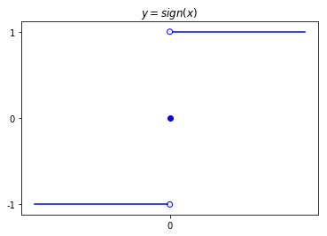

```python
plt.show()
```

## 隨堂練習

- 自訂平均數函數 `mean_fun()`

```
def mean_fun(x):
    # 撰寫您的答案
    return # 您的答案
```

## 自訂函數（5）

- 計算圓形的面積或周長

```python
import math # 要使用 pi 得引入套件 math

# 定義自訂函數
def circle_calculate(radius, is_area):
    '''
    依據輸入的半徑與 is_area 參數，計算圓形的面積或周長
    '''
    circle_area = math.pi * radius**2
    circle_circum = 2 * math.pi * radius
    if is_area == True:
        return circle_area
    else:
        return circle_circum

# 呼叫自訂函數
help(circle_calculate) # 查詢自訂函數
my_radius = 3
print(circle_calculate(my_radius, is_area = True)) # 指定參數回傳面積
print(circle_calculate(my_radius, is_area = False)) # 指定參數回傳周長
```

```
Help on function circle_calculate in module __main__:

circle_calculate(radius, is_area)
    依據輸入的半徑與 is_area 參數，計算圓形的面積或周長

28.274333882308138
18.84955592153876
```

## 隨堂練習

- 給 `is_area` 一個預設值 `True`，預設計算圓形的面積

## 自訂函數（7）

- 在 `return` 後面將多個值用逗號 `,` 隔開就會回傳一個 tuple

```python
import math # 要使用 pi 得引入套件 math

# 定義自訂函數
def circle_calculate(radius):
    '''
    依據輸入的半徑同時計算並回傳圓形的面積與周長
    '''
    circle_area = math.pi * radius**2
    circle_circum = 2 * math.pi * radius
    return circle_area, circle_circum

# 呼叫自訂函數
my_radius = 3
print(circle_calculate(my_radius))
circle_area, circle_circum = circle_calculate(my_radius)
print(circle_area)
print(circle_circum)
```

```
(28.274333882308138, 18.84955592153876)
28.274333882308138
18.84955592153876
```

## 自訂函數（9）

- 交換排序法（遞增）

```python
import numpy as np

# 定義自訂函數
def exchange_sort(x):
    '''
    依據輸入的 list 遞增排序 list 中的數字後回傳。
    '''
    # 遞增排序
    for i in range(0, len(x) - 1):
        for j in range(i + 1, len(x)):
            # 如果前一個數字比後一個數字大則交換位置
            if x[i] > x[j]:
                x[i], x[j] = x[j], x[i]

    return x

# 呼叫自訂函數
rand_int = np.random.randint(1, 100, size = 10) # 產生一組隨機數
print(rand_int) # 看看未排序前
print(exchange_sort(rand_int))
```

```
[55 31 29 79 46 86 51 59 43  6]
[ 6 29 31 43 46 51 55 59 79 86]
```

## 隨堂練習

- 在交換排序法中增加一個參數：`reverse`，預設 `reverse = False` 遞增排序

## 錯誤處理

- Python 使用 `try - except` 的語法結構進行錯誤處理

```python
import math # 要使用 pi 得引入套件 math

# 定義自訂函數
def circle_calculate(radius):
    '依據輸入的半徑同時計算並回傳圓形的面積或周長' # 單行的 docstring
    try:
        circle_area = math.pi * radius**2
        circle_circum = 2 * math.pi * radius
        return circle_area, circle_circum
    except:
        return "請輸入數值。"

# 呼叫自訂函數
my_radius = "3"
print(circle_calculate(my_radius))
```

```
請輸入數值。
```

## 錯誤處理（2）

- 在 `except` 語法後面連接錯誤的種類

```python
def divide(numerator, denominator):
    try:
        ans = numerator / denominator
        return ans
    except ZeroDivisionError:
        return "分母不可以為零！"
    except:
        return "其他的錯誤"

print(divide(5, 0))
```

```
分母不可以為零！
```

## 匿名函數

- 又稱為 `lambda` 函數
- 不需要 `def`、`return` 的敘述

```python
my_squared = lambda x : x ** 2
print(my_squared(3))
```

```
9
```

## 匿名函數（2）

- 常與內建的兩個函數一起使用：
  - `filter()`
  - `map()`

## 匿名函數（3）

- 搭配 `filter()` 將 1~10 中的奇數選出：

```python
my_list = range(1, 11)
print(list(filter(lambda x : x % 2 == 1, my_list)))
```

```
[1, 3, 5, 7, 9]
```

## 匿名函數（4）

- 搭配 `map()` 將 1~10 每個數字都平方：

```python
my_list = range(1, 11)
print(list(map(lambda x : x**2, my_list)))
```

```
[1, 4, 9, 16, 25, 36, 49, 64, 81, 100]
```

## 需要用 `list()` 才能看到輸出的函數

- `range()`
- `filter()`
- `map()`
- `enumerate()`
- `zip()`

## 隨堂練習

- 自訂函數 1：寫一個判斷輸入的正整數是否為質數的函數 `is_prime()`

```
is_prime(9)
# False
is_prime(11)
# True
```

## 隨堂練習

- 自訂函數 2：寫一個函數 `count_primes(x, y)` 計算 x 到 y 之間有幾個質數（包含 x, y）

```
count_primes(3, 7)
# 3
count_primes(3, 9)
# 3
count_primes(3, 11)
# 4
```

## 隨堂練習

- 自訂函數 3：寫一個 Fibonacci 數列的產生函數，有三個輸入：第一個數字 f1、第二個數字 f2 與數列長度 fib_len `fib_gen(f1, f2, fib_len)`

```
fib_gen(1, 1, 5)
# [1 1 2 3 5]
fib_gen(0, 1, 5)
# [0 1 1 2 3]
```